# Conspecific/heterospecific correlation growth and fecundity

[James S. Clark](http://sites.nicholas.duke.edu/clarklab/)

2022-10-04

```r
source('treeCorFunctions.r')
cols      <- c("#3288BD", "#D53E4F", "#a65628")
blueGreen <- colorRampPalette( c('#67a9cf','#3690c0','#02818a','#016450') )
```

This set of algorithms determines tree-to-tree correlation in growth and fecundity, and it summarizes correlations by conspecific and heterospecific pairs of individuals. For fecundity, it extracts annual estimates from trees on [MASTIF](https://sites.nicholas.duke.edu/clarklab/projects/forecasting-community-dynamics-the-mast-system/) sites. For diameter growth, it uses raw diameter data from MASTIF and other sites with repeated censuses. For fecundity, only seed-producing individuals are included. For growth, comparisons are restricted to individuals with a minimal number of overlapping measurements.

# tree growth

If `minCens` is too small, say 3 measurements, there will be many trees, but pairwise correlations will be poorly supported–results will be noisy. If `minCens` is too large, few trees will qualify, and the distribution of pairwise correlations will contain few values. The value for `minCens` has to balance these concerns. Diameter growth needs at least 4 censuses. Fecundity needs at least 3 censuses.

```r
minCensus( tdata, xy, minCens = 4 )
# tdata   - tree-years by variables, including plot, tree, year, diam
# xy      - trees by variables, including plot, tree, x, y
# minCens - at least 4 needed for growth, three for fecundity
```

# tile to competitive neighborhoods

Competition is local, so we need to approximate a tree’s neighborhood. The inventory plot is partitioned into neighborhoods of area `wide^2`. Each tree is assigned to one neighborhood or `tile`. The function `getTile` appends a column to `treeData` with an integer value for the competition neighborhood.

```r
getTile( tdata, wide = 40 )
# tdata - tree-years by variables, including plot, tree, year, diam, x, y
# wide  - wide of tile (m)
```

# individual (pairwise) correlation

Correlations are compiled for individuals having i) overlappling sample histories of measurement of at least `minCens` years and ii) are within the same neighborhood (`tile`). The `function treeCor` takes data for one neighborhood and compiles the individual pairwise correlations as a matrix. For growth, it returns this matrix with `NA` values for pairs that do not have the same measurement history. Diameter measurements (cm) are transformed into growth (cm/yr) prior to correlation. For fecundity, it removes individuals that are not reproductive.

```r
treeCor( tdata, varName = 'diam', minCens = 4 )
# tdata - tree-years by variables for one tile, including treeID, year, species, diam, x, y,
#         and varName, which can be 'diam' or 'fecEstMu' (fecundity)
```

The function `treeCor` returns several objects:

| Object | Structure | variables |
| --- | --- | --- |
| tileData | tile by variables | mean intra/inter cor, n, richness, diversity, density |
| corTile | spp by spp | mean pairwise correlation |
| covTile | spp by spp | mean pairwise covariance |
| ncomp | spp by spp | no. of pairwise comparisons |
| xmu | tile by spp | mean response (‘diam’ or ‘fecEstMu’) |
| xvar | tile by spp | variance of response |
| ntree | by spp | no. trees |

# compiling tile correlations

The `function tileCorrelation` takes the `data.frame treeData`, which includes the `tile` column, and returns a summary `matrix` of correlation data. The rows are tile numbers. The columns include the mean intra- and inter-specific correlations for that tile (`'intraMu', 'interMu'`) and the 90% interval (`'intra05', 'intra95', 'inter05', 'inter95'`).

```r
tileCorrelation( tdata, wide, varName = 'diam', FULLCOR = F ){
  # tdata requires a tile column, 1, 2, ...
  # returns:
  # corMat    - tile by mean pairwise correlation differences
  # covMatrix - species by species mean covariances (not a covariance matrix)
  # growth    - mean species growth
```

Here is an example for diameter growth for BCI data.

```r
load( 'treeData_diam/BCI.rdata', verbose = T )

wide      <- 30
treeData  <- minCensus( treeData, xytree, minCens = 4 )
treeData  <- getTile( treeData, wide = wide )
bciCor    <- tileCorrelation( treeData, wide = wide, varName = 'diam' )
tileData  <- bciCor$tileData
covMatrix <- bciCor$covMatrix
corMatrix <- bciCor$corMatrix
comMatrix <- bciCor$comMatrix
xmu       <- bciCor$xmu
xse       <- bciCor$xse
ntree     <- bciCor$ntree
```

Here is the tiled stem map for BCI:

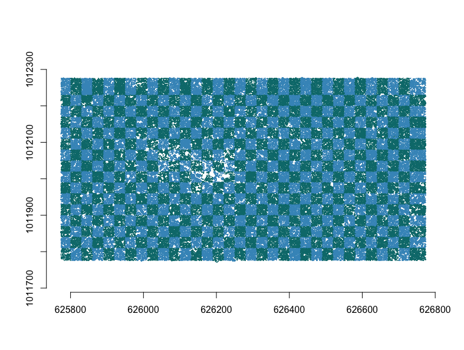

Thirty-meter tiles for BCI. Correlations between trees are evaluated at this scale, defined by parameter `wide`.

```r
par( bty='n')
plot( treeData$x, treeData$y, cex = treeData$diam/200,
      col = blueGreen(5)[ 2*(1 + treeData$tile %% 2) ],
      asp = 1, xlab = '', ylab = '')
```

The function `tileCorrelation` returns several objects:

| Object | Structure | variables |
| --- | --- | --- |
| tileData | tile by variables | mean intra/inter correlation, n, richness, diversity, density |
| corMatrix | spp by spp | mean pairwise correlation |
| covMatrix | spp by spp | mean pairwise covariance |
| comMatrix | spp by spp | no. of pairwise comparisons |
| xmu | tile by spp | mean response (‘diam’ or ‘fecEstMu’) |
| xse | tile by spp | SE of response |
| ntree | tile by spp | no. of trees |

The value `NA` is used where there are insufficient comparisons.

```r
library( corrplot )
corMatrix[ !is.finite(corMatrix) ] <- 0
covMatrix[ !is.finite(covMatrix) ] <- 0
corrplot( t(corMatrix), is.corr = T, type = 'lower', order = 'hclust', tl.pos = 'n',
          addgrid.col = NA)
```

The differences in scale for species makes the covariance matrix hard to plot (most values are white). Here is the matrix of correlations:

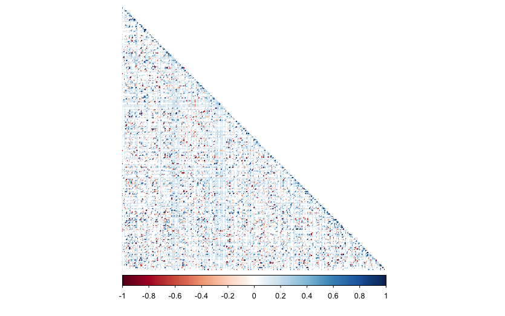

This code plots histograms:

```r
par( mfrow=c(1,2), bty='n', omi = c(.2, .1, .1, .1) )
corHist( tileData[,2], ylab = 'Frequency', col = cols[2] )
corHist( tileData[,1], add = T )
legend( 'topright', c('intra','inter'), text.col = cols, bty='n')
title( 'a) Pairwise correlations', font.main = 6 )

corHist( tileData[,1] - tileData[,2], col = 'white', xlim = c(-.05, .2), ylim = c(0, 6) )
abline( v = 0, col = 'white', lwd=3)
abline( v = 0, lty=2, col = 'grey', lwd=3)
corHist( tileData[,1] - tileData[,2], col = cols[3], add = T )
title( 'b) Intra- minus inter-specific', font.main = 6 )
mtext('Correlation', 1, outer=T, line = -1.5, cex = 1.2)
```

Below are histograms for mean correlations between individuals of the same and different species within a neighborhood (tile) at BCI. At right is the histogram of correlation differences.

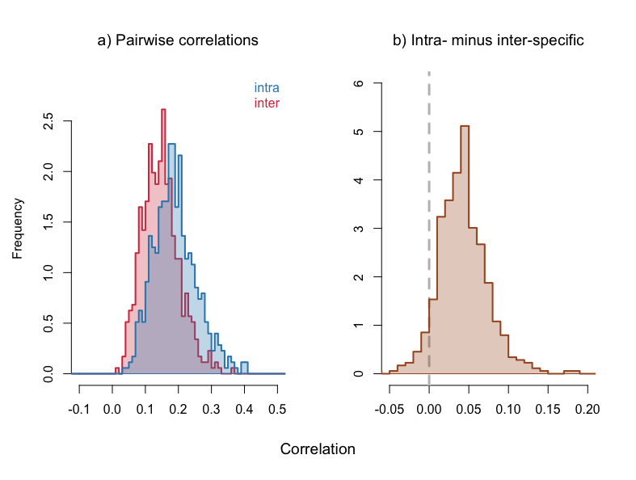

Histograms of mean tile correlations between tree growth rates for intra- and inter-specific comparisons (left) with their difference (right) for BCI.

The next block uses the function `getData` to merge sites by biome. To change this grouping edit your version of the function `groupSites( sites )` in the file `treeCorFunctions.R`. Here are comparisons for diameter data from multiple sites:

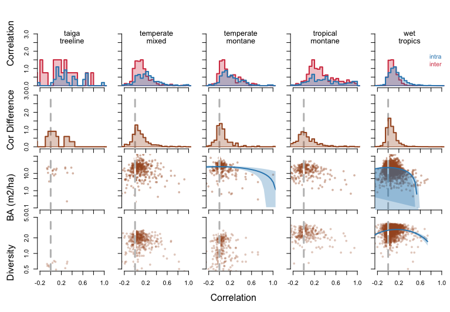

Intra- and inter-specific comparisons (first row) for diameter growth, with the difference histogram (2nd row). The two rows at bottom plot the correlation difference against the tile density and diversity (Shannon entropy).

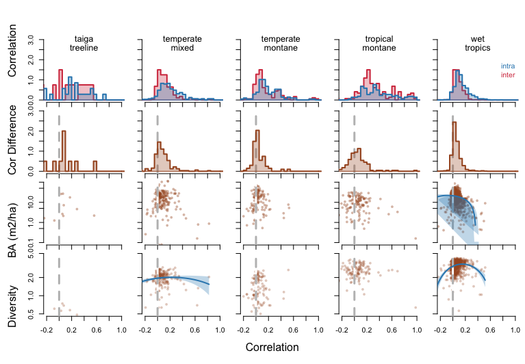

Same as above with wide = 50 m.

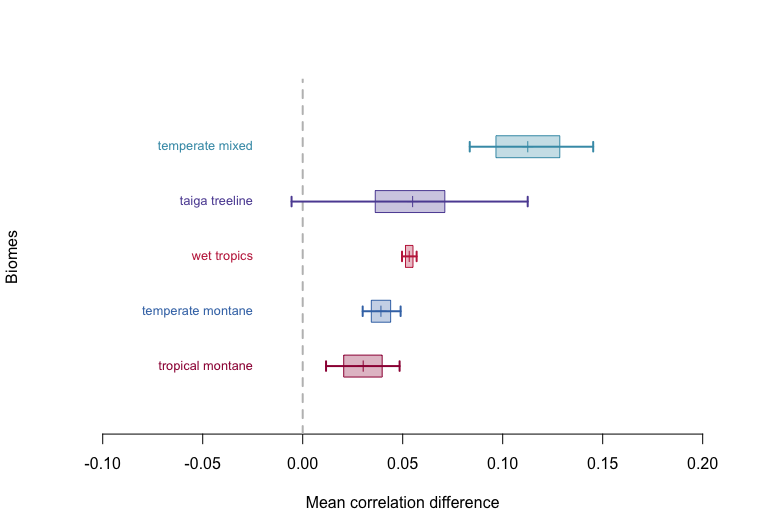

Mean correlation difference by site for diameter growth.

```r
wide    <- 30
varName <- 'diam'
minCens <- 4
minDiam <- 5

tmp <- getData( varName, wide, minCens, minDiam = minDiam )
tileList <- tmp$tileList
corList  <- tmp$corList
covList  <- tmp$covList
comList  <- tmp$comList
     xmu <- tmp$xmu
     xse <- tmp$xse

tileList <- tileList[ sapply(tileList, nrow) > 10 ]

dlim    <- c(-.2, 1)
breaks  <- seq( -1.5, 1.5, by = .05 )
words   <- plotSetup(names(tileList))
np      <- nrow(words)
xlabels <- ylabels <- F

for( j in 1:np){

  ylabels <- F
  yaxt    <- 'n'
  if( j == 1 ){
    ylabels <- T
    yaxt <- 's'
  }

  tmp <- mergeCov( tileList[j], covList[j], corList[j], comList[j], cint = .04 )
  x   <- tmp$density
  tl  <- tmp$tileList
  st  <- tmp$stats

  corHist( tl[,2], col = cols[2], xlim = dlim, ylim = c(0, 3),
           breaks = breaks, xaxt = 'n', yaxt = yaxt )
  corHist( tl[,1], col = cols[1], breaks = breaks, add = T )
  title( words[j,1], font.main= 6, line = -.5, cex=.9 )
  title( words[j,2], font.main= 6, line = -1.5, cex=.9 )
  if( j == np )legend( 'right', c('intra','inter'), text.col = cols, bty='n')

  corHist( tl[,1] - tl[,2], col = 'white', xlim = dlim, ylim = c(0, 3),
           breaks = breaks, xaxt = 'n', yaxt = yaxt )
  abline( v = 0, col = 'white', lwd=3)
  abline( v = 0, lty=2, col = 'grey', lwd=3)
  corHist( tl[,1] - tl[,2], col = cols[3], breaks = breaks, add = T )

  ylim <- c(.1,100)
  dif <- tl[,1] - tl[,2]
  wf  <- which( is.finite(dif) )
  plot( dif, tl[,'BA'], xaxt = 'n', ylim = ylim, yaxt = 'n',
        xlab = '', ylab = '', xlim = dlim, log = 'y',  cex=.8,
        pch = 16, col = .getColor( cols[3], .4) )
  axis( 2, labels = ylabels)
  axis( 1, labels = F )
  abline( v = 0, lwd = 3, col = 'white' )
  abline( v = 0, lwd = 3, lty = 2, col = 'grey' )
  if( length(wf) > 5 )reg2plot( dif, tl[,'BA'], col = cols[1], p = .1, ylim = ylim )

  ylim <- c(.5,5)
  plot( dif, tl[,'diversity'], xaxt = 'n', yaxt = 'n',
        xlab = '', ylab = '', ylim = ylim, log = 'y', xlim = dlim, cex=.8,
        pch = 16, col = .getColor( cols[3], .3) )
  axis( 2, labels = ylabels)
  axis( 1, labels = T )
  abline( v = 0, lwd = 3, col = 'white' )
  abline( v = 0, lwd = 3, lty = 2, col = 'grey' )
  if( length(wf) > 5 )reg2plot( dif, tl[,'diversity'], col = cols[1], p = .1, ylim = ylim )
}

mtext( paste0( c( 'Diversity', 'BA (m2/ha)', 'Cor Difference', 'Correlation'  ),
               collapse = '         '), 2, outer=T, line = 1 )
mtext( 'Correlation', 1, outer = T, line = 3 )
```

# fecundity estimates

Fecundity estimates from MASTIF can be evaluated using the same code. In the previous block, I change `varName <- fecEstMu`, and `minCens <- 3`. Here are plots:

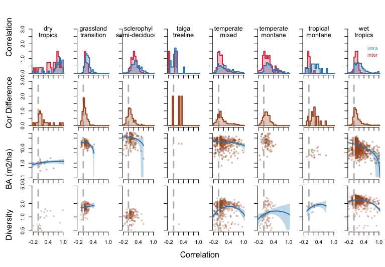

Intra- and inter-specific comparisons (first row) for fecundity, with the difference histogram (2nd row). The two rows at bottom plot the correlation difference against the tile density and diversity (Shannon entropy).

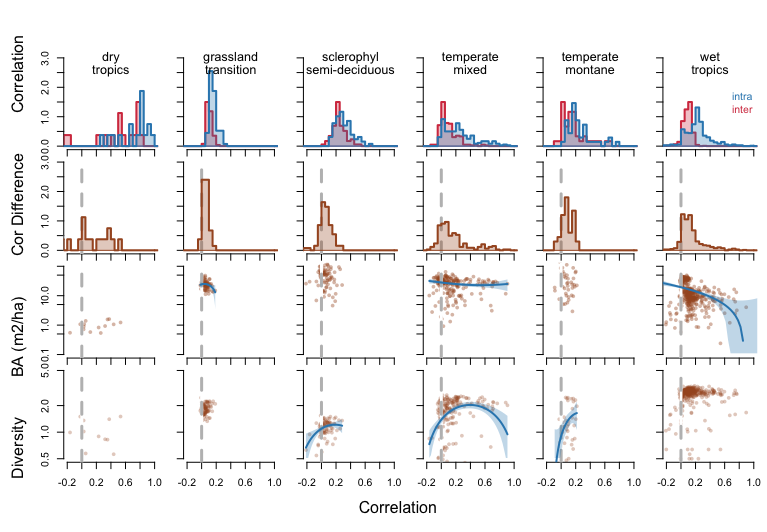

Same as previous with wide = 50 m.

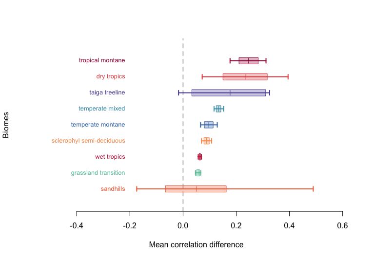

Mean correlation difference by site for fecundity.